# dataframe

Autogenerated data summary from dataMaid

2022-07-23 01:03:01

# Data report overview

The dataset examined has the following dimensions:

| Feature | Result |
| --- | --- |
| Number of observations | 612287 |
| Number of variables | 41 |

### Checks performed

The following variable checks were performed, depending on the data type of each variable:

|  | character | factor | labelled | haven labelled | numeric | integer | logical | Date |
| --- | --- | --- | --- | --- | --- | --- | --- | --- |
| Identify miscoded missing values | × | × | × | × | × | × |  | × |
| Identify prefixed and suffixed whitespace | × | × | × | × |  |  |  |  |
| Identify levels with < 6 obs. | × | × | × | × |  |  |  |  |
| Identify case issues | × | × | × | × |  |  |  |  |
| Identify misclassified numeric or integer variables | × | × | × | × |  |  |  |  |
| Identify outliers |  |  |  |  | × | × |  | × |

Please note that all numerical values in the following have been rounded to 2 decimals.

# Summary table

|  | Variable class | # unique values | Missing observations | Any problems? |
| --- | --- | --- | --- | --- |
| flight_id | factor | 5354 | 0.00 % | × |
| airline_icao | factor | 37 | 0.00 % | × |
| linetype_code | factor | 8 | 0.00 % |  |
| origin_icao | factor | 86 | 0.00 % | × |
| expected_depart_date | Date | 365 | 0.00 % |  |
| expected_depart_hour | factor | 24 | 0.00 % | × |
| real_depart_date | Date | 365 | 0.00 % |  |
| real_depart_hour | factor | 24 | 0.00 % | × |
| expected_duration | numeric | 250 | 0.00 % | × |
| departure_delay | numeric | 799 | 0.00 % | × |
| depart_temperature | numeric | 41 | 0.00 % | × |
| depart_dew_point | numeric | 42 | 0.00 % | × |
| depart_humidity | numeric | 723 | 0.00 % |  |
| depart_visibility | numeric | 62 | 0.00 % | × |
| depart_ceiling | numeric | 62 | 0.00 % | × |
| depart_wind_speed | numeric | 37 | 0.00 % | × |
| ds_depart_wind_speed | factor | 11 | 0.00 % | × |
| depart_wind_direction | numeric | 39 | 0.00 % |  |
| ds_depart_wind_direction | factor | 17 | 0.00 % |  |
| ds_depart_day_period | ordered | 7 | 0.00 % |  |
| destination_icao | factor | 89 | 0.00 % | × |
| expected_arrival_date | Date | 366 | 0.00 % |  |
| expected_arrival_hour | factor | 24 | 0.00 % | × |
| real_arrival_date | Date | 365 | 0.00 % |  |
| real_arrival_hour | factor | 24 | 0.00 % | × |
| real_duration | numeric | 253 | 0.00 % | × |
| arrival_delay | numeric | 813 | 0.00 % | × |
| arrival_temperature | numeric | 42 | 0.00 % | × |
| arrival_dew_point | numeric | 41 | 0.00 % | × |
| arrival_humidity | numeric | 718 | 0.00 % |  |
| arrival_visibility | numeric | 65 | 0.00 % | × |
| arrival_cloudiness | factor | 7 | 0.00 % | × |
| arrival_ceiling | numeric | 67 | 0.00 % | × |
| arrival_wind_speed | numeric | 40 | 0.00 % | × |
| ds_arrival_wind_speed | factor | 12 | 0.00 % | × |
| arrival_wind_direction | numeric | 39 | 0.00 % |  |
| ds_arrival_wind_direction | factor | 17 | 0.00 % |  |
| ds_arrival_day_period | ordered | 7 | 0.00 % |  |
| situation_type | factor | 1 | 0.00 % | × |
| Partida_Atrasada | character | 2 | 0.00 % |  |
| Chegada_Atrasada | character | 2 | 0.00 % |  |

# Variable list

## flight_id

| Feature | Result |
| --- | --- |
| Variable type | factor |
| Number of missing obs. | 0 (0 %) |
| Number of unique values | 5354 |
| Mode | “5317” |
| Reference category | 0002 |

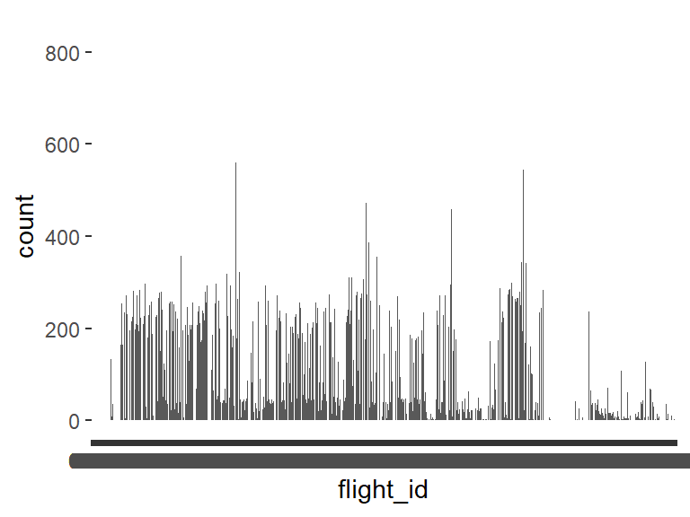

- The following suspected missing value codes enter as regular values: "9999".
- Note that the following levels have at most five observations: "0006", "0012", "0014", "0053", "0057", …, "Z9061", "Z9080", "Z9086", "Z9256", "Z9274" (738 values omitted).

## airline_icao

| Feature | Result |
| --- | --- |
| Variable type | factor |
| Number of missing obs. | 0 (0 %) |
| Number of unique values | 37 |
| Mode | “AZU” |
| Reference category | AAL |

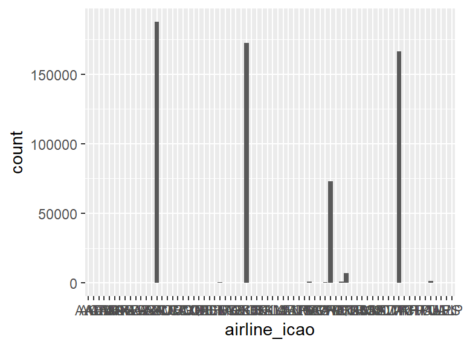

- Note that the following levels have at most five observations: "AAL", "AEA", "AFR", "AMX", "ARG", …, "LAN", "LAP", "LPE", "MPH", "UAE" (6 values omitted).

## linetype_code

[output not shown]

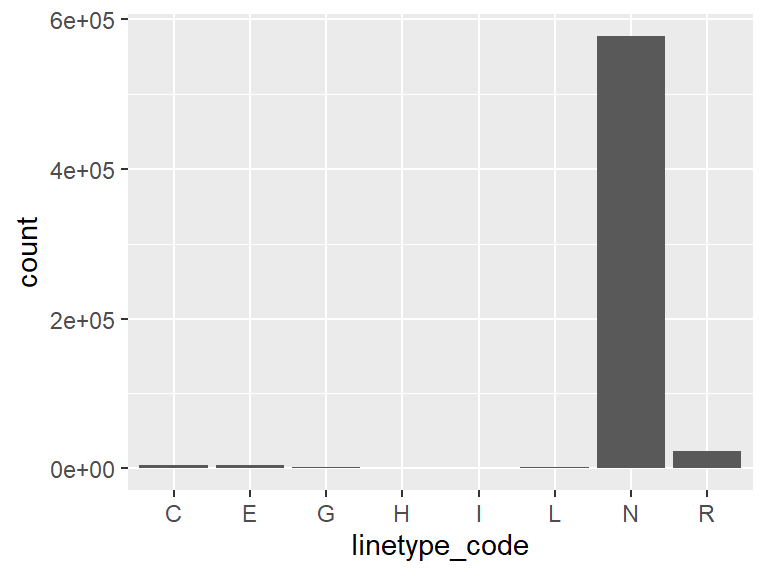

## origin_icao

| Feature | Result |
| --- | --- |
| Variable type | factor |
| Number of missing obs. | 0 (0 %) |
| Number of unique values | 86 |
| Mode | “SBGR” |
| Reference category | CYYZ |

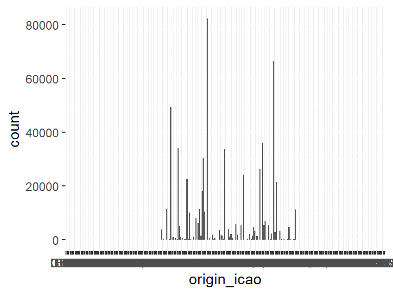

- Note that the following levels have at most five observations: "SBML", "SBMN".

## expected_depart_date

| Feature | Result |
| --- | --- |
| Variable type | Date |
| Number of missing obs. | 0 (0 %) |
| Number of unique values | 365 |
| Mode | “2018-07-23” |
| Min. and max. | 2018-01-01; 2018-12-31 |
| 1st and 3rd quartiles | 2018-05-04; 2018-10-10 |

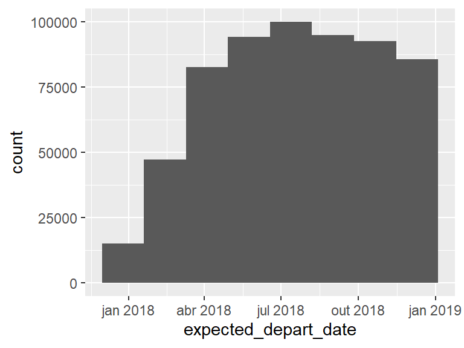

## expected_depart_hour

| Feature | Result |
| --- | --- |
| Variable type | factor |
| Number of missing obs. | 0 (0 %) |
| Number of unique values | 24 |
| Mode | “09” |
| Reference category | 00 |

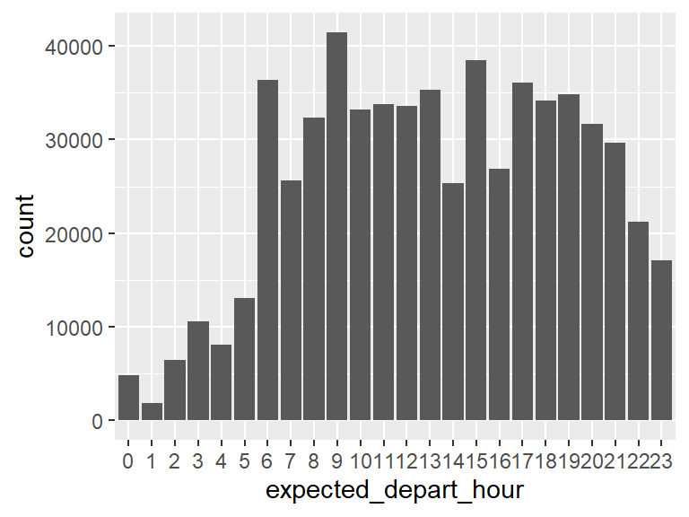

- Note: The variable consists exclusively of numbers and takes a lot of different values. Is it perhaps a misclassified numeric variable?

## real_depart_date

| Feature | Result |
| --- | --- |
| Variable type | Date |
| Number of missing obs. | 0 (0 %) |
| Number of unique values | 365 |
| Mode | “2018-12-21” |
| Min. and max. | 2018-01-01; 2018-12-31 |
| 1st and 3rd quartiles | 2018-05-04; 2018-10-10 |

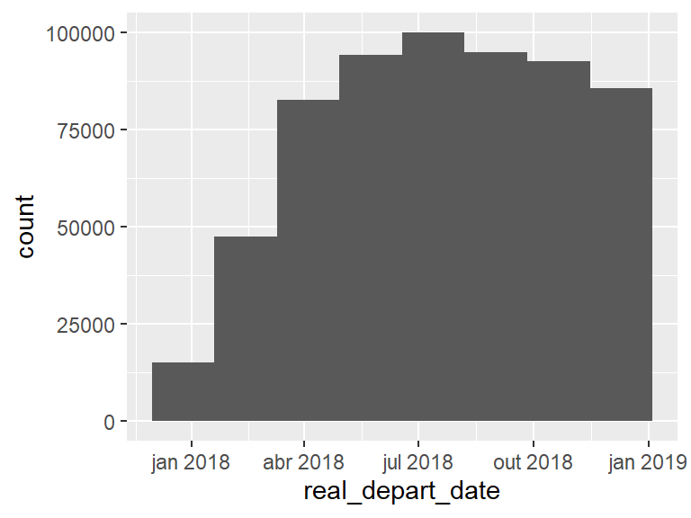

## real_depart_hour

| Feature | Result |
| --- | --- |
| Variable type | factor |
| Number of missing obs. | 0 (0 %) |
| Number of unique values | 24 |
| Mode | “09” |
| Reference category | 00 |

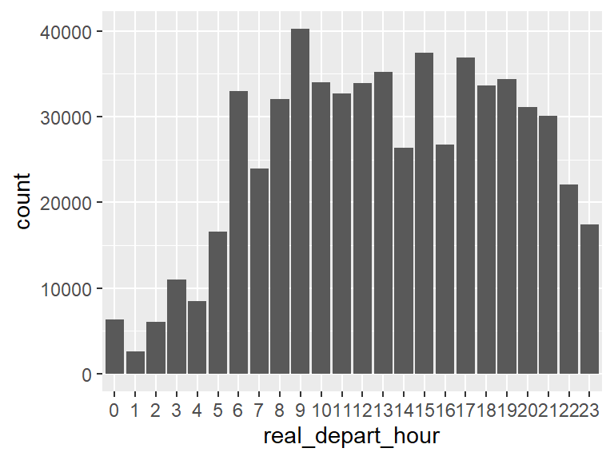

- Note: The variable consists exclusively of numbers and takes a lot of different values. Is it perhaps a misclassified numeric variable?

## expected_duration

| Feature | Result |
| --- | --- |
| Variable type | numeric |
| Number of missing obs. | 0 (0 %) |
| Number of unique values | 250 |
| Median | 95 |
| 1st and 3rd quartiles | 70; 135 |
| Min. and max. | 14; 436 |

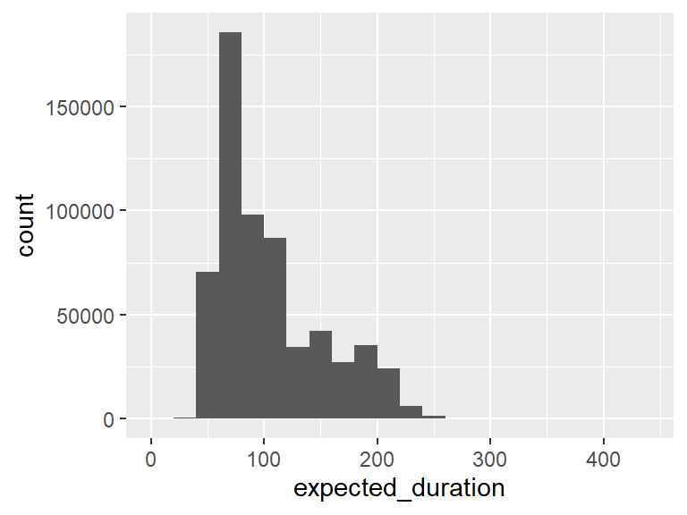

- Note that the following possible outlier values were detected: "14", "30", "35", "436".

## departure_delay

| Feature | Result |
| --- | --- |
| Variable type | numeric |
| Number of missing obs. | 0 (0 %) |
| Number of unique values | 799 |
| Median | 0 |
| 1st and 3rd quartiles | -5; 7 |
| Min. and max. | -41755; 1439 |

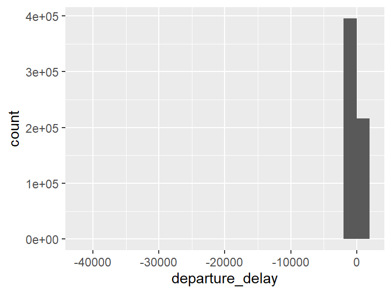

- Note that the following possible outlier values were detected: "-41755", "-1960", "-1478", "-1463", "-1459", …, "1435", "1436", "1437", "1438", "1439" (715 values omitted).

## depart_temperature

| Feature | Result |
| --- | --- |
| Variable type | numeric |
| Number of missing obs. | 0 (0 %) |
| Number of unique values | 41 |
| Median | 23 |
| 1st and 3rd quartiles | 19; 27 |
| Min. and max. | 0; 39 |

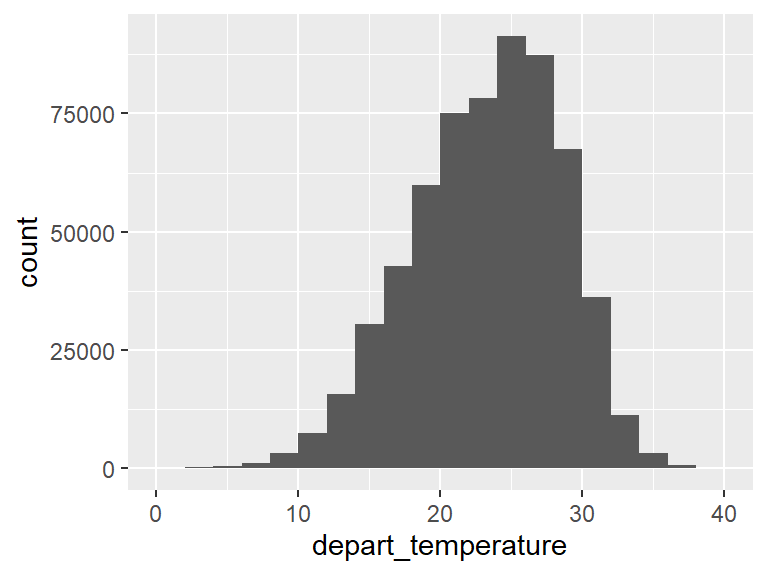

- Note that the following possible outlier values were detected: "0", "1", "2", "3", "4", "5", "6", "39".

## depart_dew_point

| Feature | Result |
| --- | --- |
| Variable type | numeric |
| Number of missing obs. | 0 (0 %) |
| Number of unique values | 42 |
| Median | 18 |
| 1st and 3rd quartiles | 14; 21 |
| Min. and max. | -9; 36 |

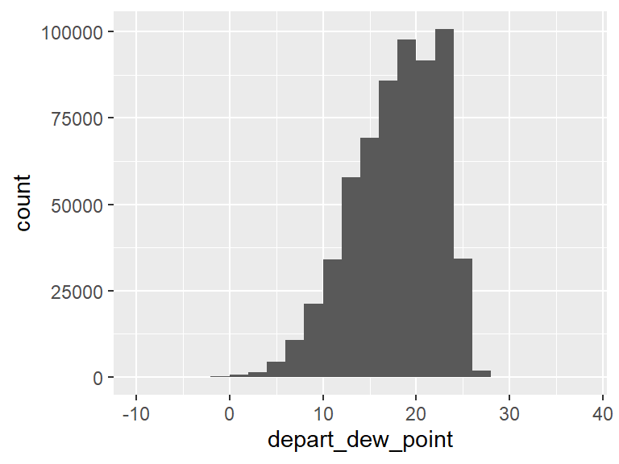

- Note that the following possible outlier values were detected: "-9", "-6", "-5", "-4", "-3", …, "29", "30", "31", "33", "36" (3 values omitted).

## depart_humidity

| Feature | Result |
| --- | --- |
| Variable type | numeric |
| Number of missing obs. | 0 (0 %) |
| Number of unique values | 723 |
| Median | 77.29 |
| 1st and 3rd quartiles | 62.47; 88.26 |
| Min. and max. | 7; 100 |

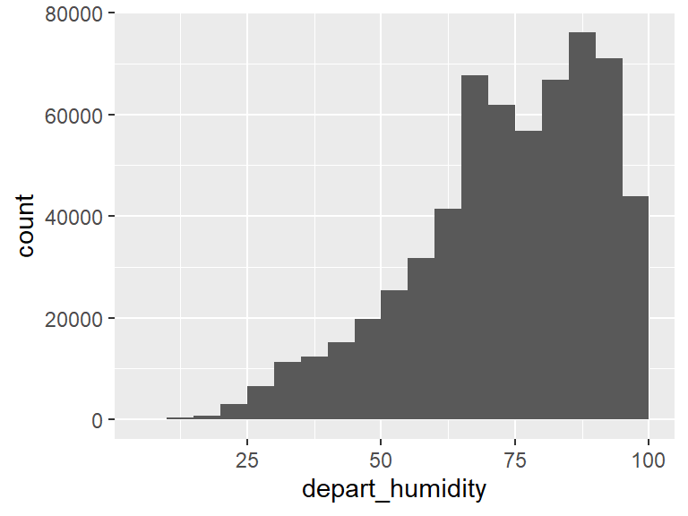

## depart_visibility

| Feature | Result |
| --- | --- |
| Variable type | numeric |
| Number of missing obs. | 0 (0 %) |
| Number of unique values | 62 |
| Median | 6.21 |
| 1st and 3rd quartiles | 6.21; 6.21 |
| Min. and max. | 0.03; 6.21 |

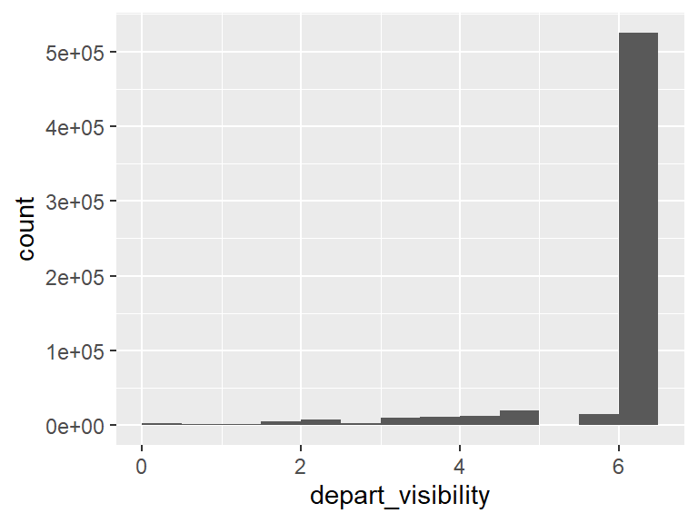

- Note that the following possible outlier values were detected: "0.03", "0.06", "0.09", "0.12", "0.16", …, "3.11", "3.73", "4.35", "4.97", "5.59" (51 values omitted).

## depart_ceiling

| Feature | Result |
| --- | --- |
| Variable type | numeric |
| Number of missing obs. | 0 (0 %) |
| Number of unique values | 62 |
| Median | 2059.58 |
| 1st and 3rd quartiles | 1295.15; 3134.95 |
| Min. and max. | 0; 9000 |

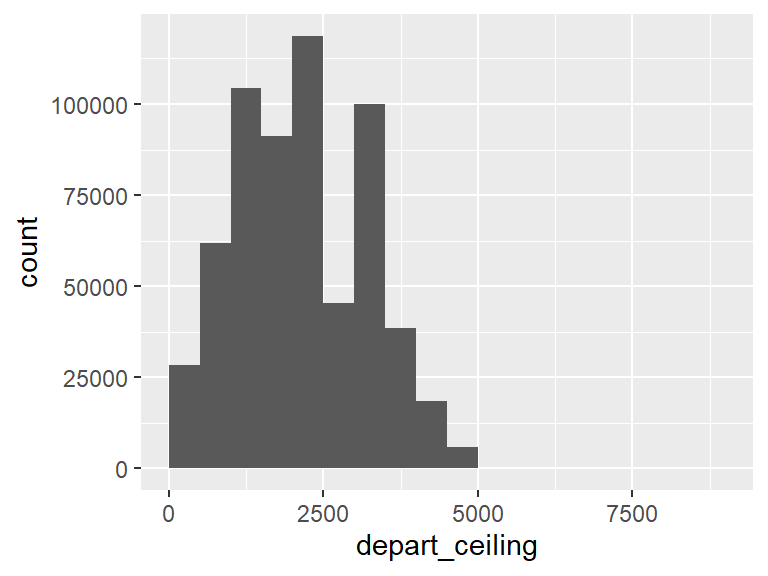

- Note that the following possible outlier values were detected: "8000", "8500", "9000".

## depart_wind_speed

| Feature | Result |
| --- | --- |
| Variable type | numeric |
| Number of missing obs. | 0 (0 %) |
| Number of unique values | 37 |
| Median | 6 |
| 1st and 3rd quartiles | 4; 9 |
| Min. and max. | 0; 109 |

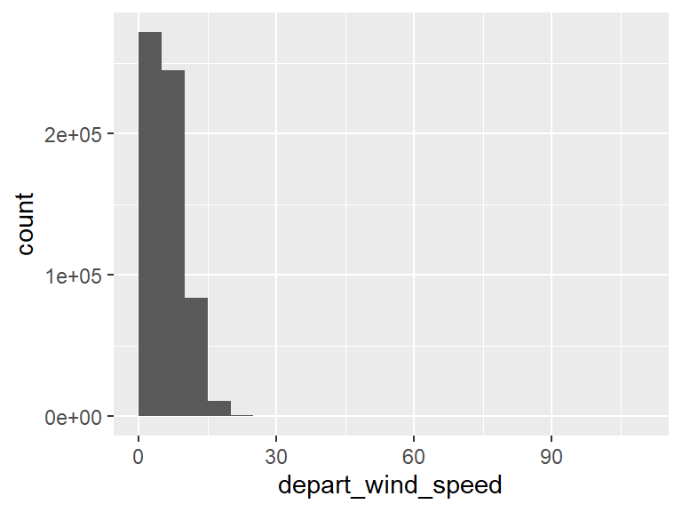

- Note that the following possible outlier values were detected: "21", "22", "23", "24", "25", …, "34", "39", "40", "50", "109" (5 values omitted).

## ds_depart_wind_speed

| Feature | Result |
| --- | --- |
| Variable type | factor |
| Number of missing obs. | 0 (0 %) |
| Number of unique values | 11 |
| Mode | “Light Breeze” |
| Reference category | Calm |

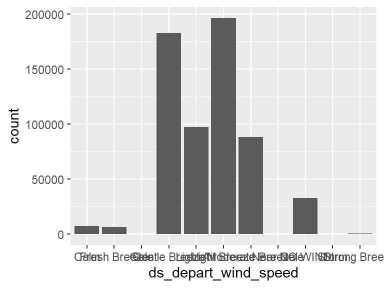

- Note that the following levels have at most five observations: "Storm".

## depart_wind_direction

| Feature | Result |
| --- | --- |
| Variable type | numeric |
| Number of missing obs. | 0 (0 %) |
| Number of unique values | 39 |
| Median | 120 |
| 1st and 3rd quartiles | 70; 190 |
| Min. and max. | 0; 360 |

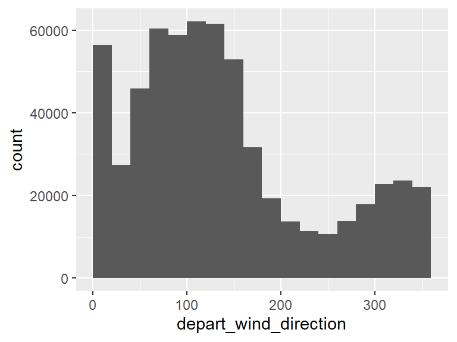

## ds_depart_wind_direction

| Feature | Result |
| --- | --- |
| Variable type | factor |
| Number of missing obs. | 0 (0 %) |
| Number of unique values | 17 |
| Mode | “E” |
| Reference category | E |

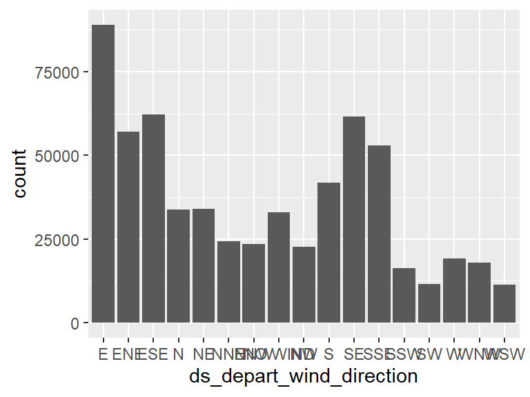

## ds_depart_day_period

| Feature | Result |
| --- | --- |
| Variable type | ordered |
| Number of missing obs. | 0 (0 %) |
| Number of unique values | 7 |
| Mode | “Afternoon” |
| Reference category | Night |

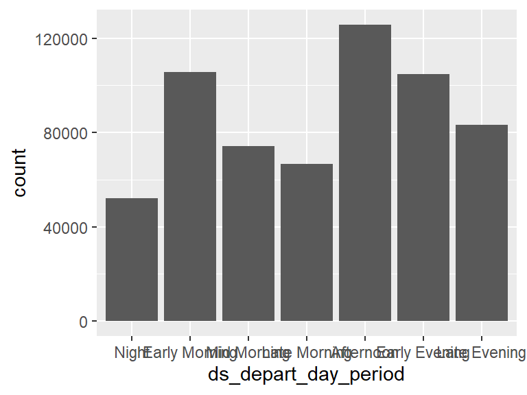

## destination_icao

| Feature | Result |
| --- | --- |
| Variable type | factor |
| Number of missing obs. | 0 (0 %) |
| Number of unique values | 89 |
| Mode | “SBGR” |
| Reference category | CYYZ |

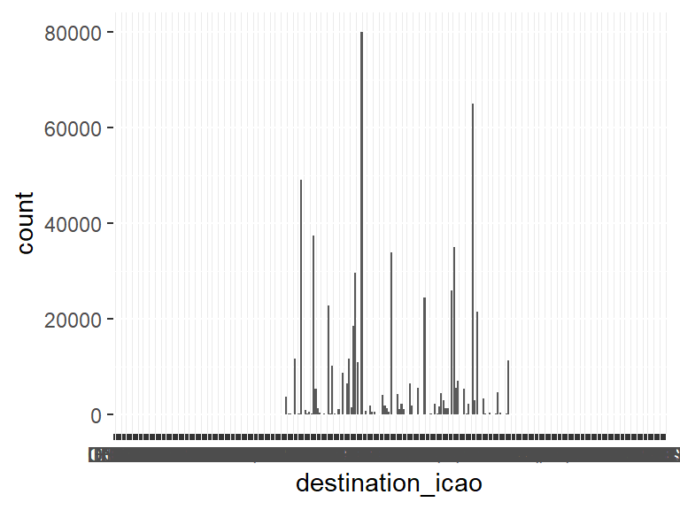

- Note that the following levels have at most five observations: "SBMN", "SBNT", "SBUA".

## expected_arrival_date

| Feature | Result |
| --- | --- |
| Variable type | Date |
| Number of missing obs. | 0 (0 %) |
| Number of unique values | 366 |
| Mode | “2018-07-23” |
| Min. and max. | 2018-01-01; 2019-01-01 |
| 1st and 3rd quartiles | 2018-05-04; 2018-10-10 |

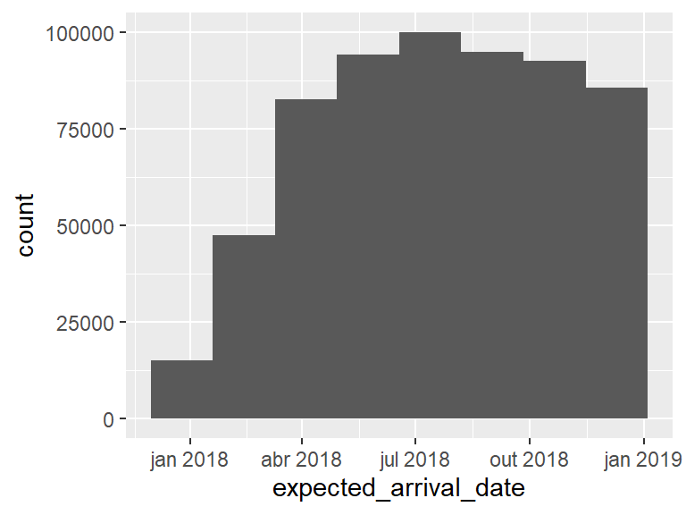

## expected_arrival_hour

| Feature | Result |
| --- | --- |
| Variable type | factor |
| Number of missing obs. | 0 (0 %) |
| Number of unique values | 24 |
| Mode | “11” |
| Reference category | 00 |

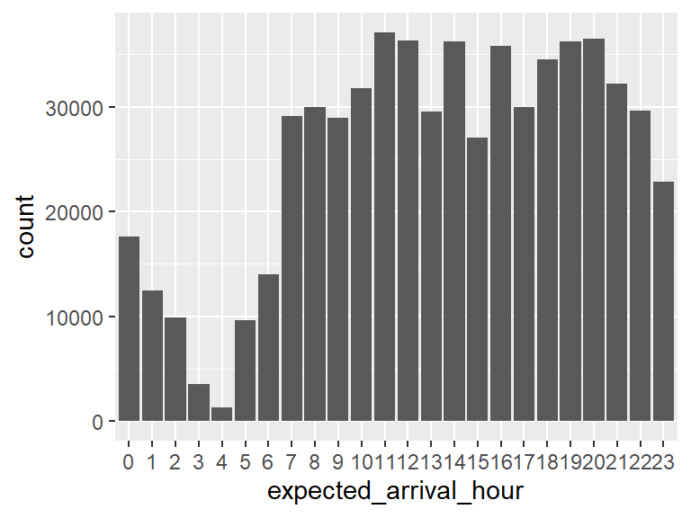

- Note: The variable consists exclusively of numbers and takes a lot of different values. Is it perhaps a misclassified numeric variable?

## real_arrival_date

| Feature | Result |
| --- | --- |
| Variable type | Date |
| Number of missing obs. | 0 (0 %) |
| Number of unique values | 365 |
| Mode | “2018-12-21” |
| Min. and max. | 2018-01-01; 2018-12-31 |
| 1st and 3rd quartiles | 2018-05-04; 2018-10-10 |

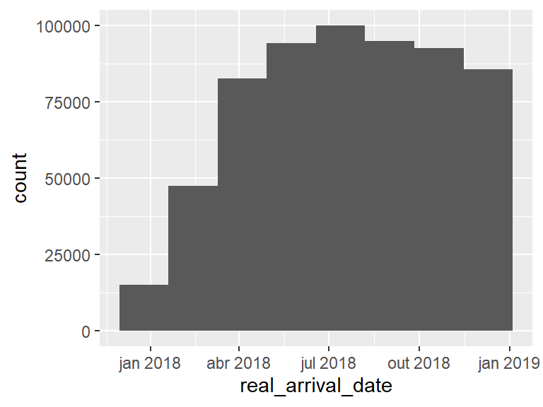

## real_arrival_hour

| Feature | Result |
| --- | --- |
| Variable type | factor |
| Number of missing obs. | 0 (0 %) |
| Number of unique values | 24 |
| Mode | “20” |
| Reference category | 00 |

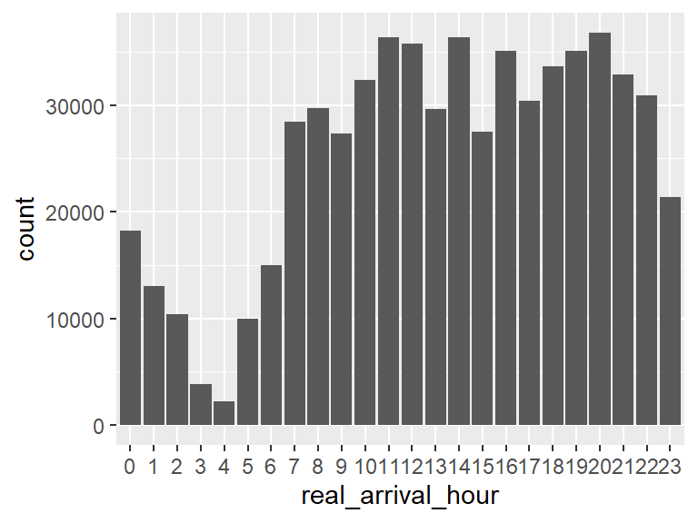

- Note: The variable consists exclusively of numbers and takes a lot of different values. Is it perhaps a misclassified numeric variable?

## real_duration

| Feature | Result |
| --- | --- |
| Variable type | numeric |
| Number of missing obs. | 0 (0 %) |
| Number of unique values | 253 |
| Median | 91 |
| 1st and 3rd quartiles | 69; 130 |
| Min. and max. | 45; 436 |

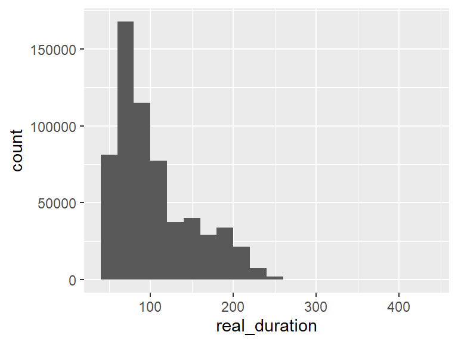

- Note that the following possible outlier values were detected: "436".

## arrival_delay

| Feature | Result |
| --- | --- |
| Variable type | numeric |
| Number of missing obs. | 0 (0 %) |
| Number of unique values | 813 |
| Median | 0 |
| 1st and 3rd quartiles | -9; 7 |
| Min. and max. | -41737; 1439 |

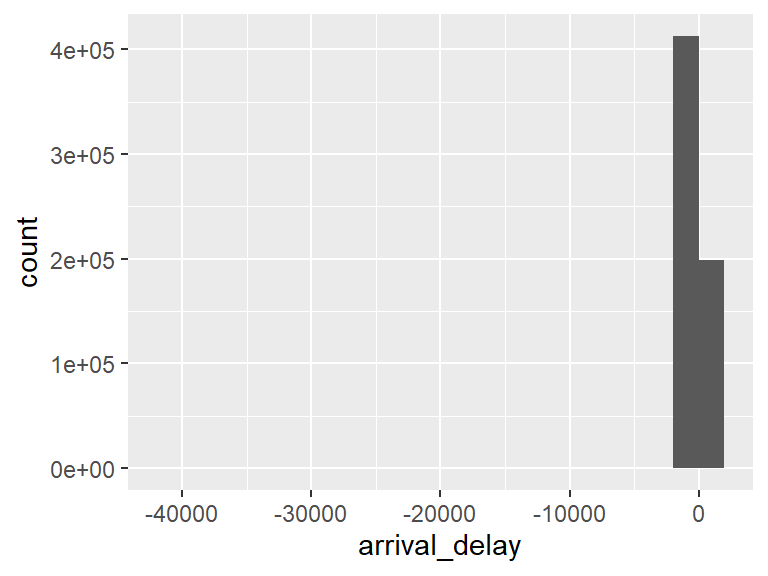

- Note that the following possible outlier values were detected: "-41737", "-1952", "-1499", "-1464", "-1462", …, "1435", "1436", "1437", "1438", "1439" (735 values omitted).

## arrival_temperature

| Feature | Result |
| --- | --- |
| Variable type | numeric |
| Number of missing obs. | 0 (0 %) |
| Number of unique values | 42 |
| Median | 23 |
| 1st and 3rd quartiles | 19; 27 |
| Min. and max. | 0; 40 |

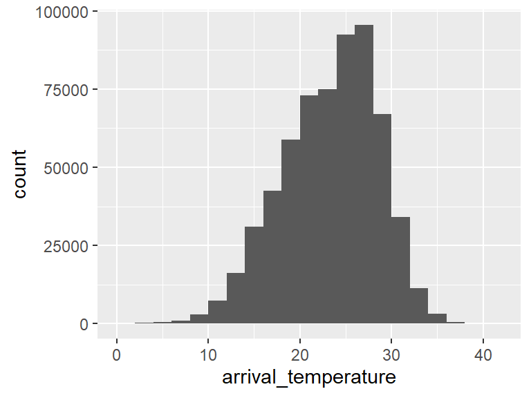

- Note that the following possible outlier values were detected: "0", "1", "2", "3", "4", "37", "38", "39", "40".

## arrival_dew_point

| Feature | Result |
| --- | --- |
| Variable type | numeric |
| Number of missing obs. | 0 (0 %) |
| Number of unique values | 41 |
| Median | 18 |
| 1st and 3rd quartiles | 14; 21 |
| Min. and max. | -6; 36 |

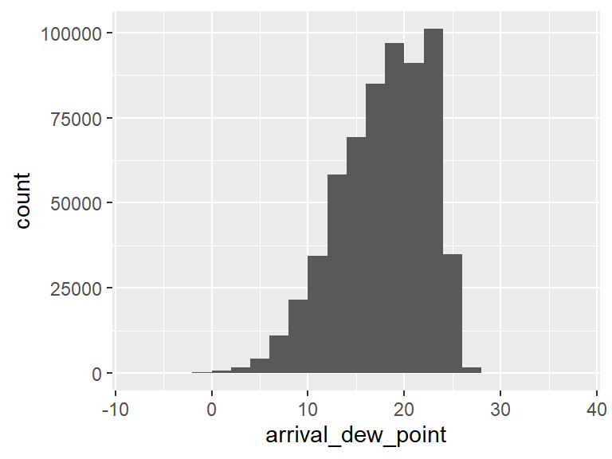

- Note that the following possible outlier values were detected: "-6", "-5", "-4", "-3", "-2", …, "29", "30", "31", "34", "36" (2 values omitted).

## arrival_humidity

| Feature | Result |
| --- | --- |
| Variable type | numeric |
| Number of missing obs. | 0 (0 %) |
| Number of unique values | 718 |
| Median | 77.45 |
| 1st and 3rd quartiles | 62.47; 88.26 |
| Min. and max. | 7; 100 |

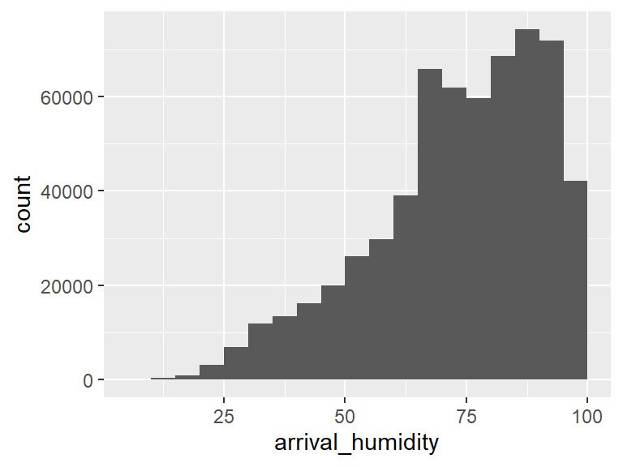

## arrival_visibility

| Feature | Result |
| --- | --- |
| Variable type | numeric |
| Number of missing obs. | 0 (0 %) |
| Number of unique values | 65 |
| Median | 6.21 |
| 1st and 3rd quartiles | 6.21; 6.21 |
| Min. and max. | 0; 6.21 |

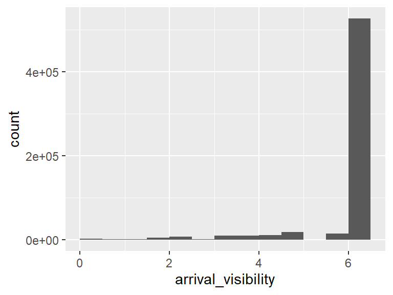

- Note that the following possible outlier values were detected: "0", "0.03", "0.06", "0.09", "0.12", …, "4.35", "4.72", "4.97", "5.59", "6.01" (54 values omitted).

## arrival_cloudiness

| Feature | Result |
| --- | --- |
| Variable type | factor |
| Number of missing obs. | 0 (0 %) |
| Number of unique values | 7 |
| Mode | “FEW” |
| Reference category | BKN |

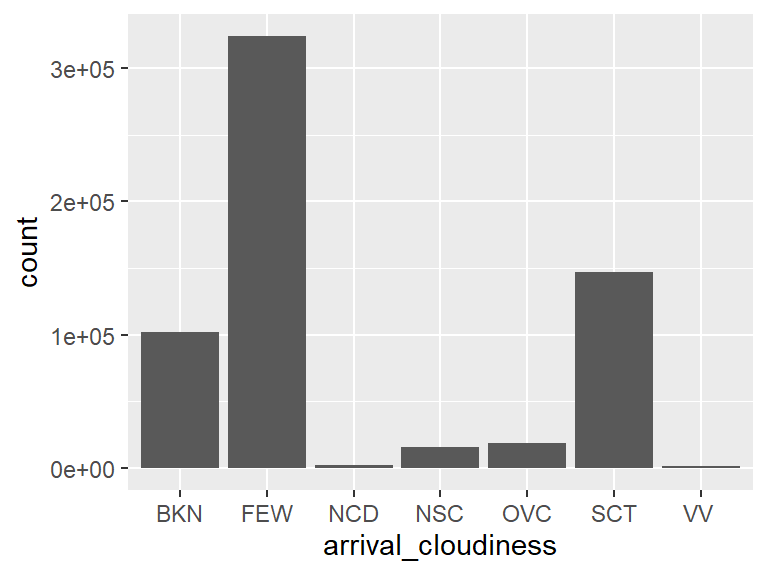

- The following values appear with prefixed or suffixed white space: "VV ".

## arrival_ceiling

| Feature | Result |
| --- | --- |
| Variable type | numeric |
| Number of missing obs. | 0 (0 %) |
| Number of unique values | 67 |
| Median | 2000 |
| 1st and 3rd quartiles | 1318.3; 3000 |
| Min. and max. | 0; 11000 |

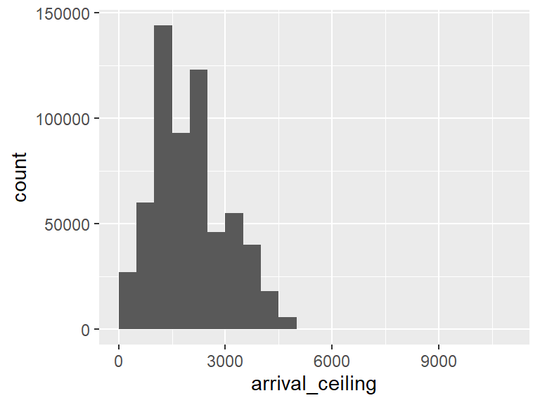

- Note that the following possible outlier values were detected: "6000", "6200", "7000", "7500", "7600", "8000", "8500", "9000", "10000", "11000".

## arrival_wind_speed

| Feature | Result |
| --- | --- |
| Variable type | numeric |
| Number of missing obs. | 0 (0 %) |
| Number of unique values | 40 |
| Median | 6 |
| 1st and 3rd quartiles | 4; 9 |
| Min. and max. | 0; 69 |

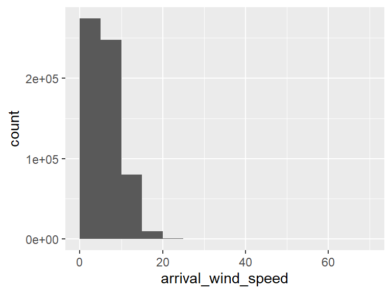

- Note that the following possible outlier values were detected: "21", "21.38", "22", "23", "24", …, "38", "39", "40", "50", "69" (8 values omitted).

## ds_arrival_wind_speed

| Feature | Result |
| --- | --- |
| Variable type | factor |
| Number of missing obs. | 0 (0 %) |
| Number of unique values | 12 |
| Mode | “Light Breeze” |
| Reference category | Calm |

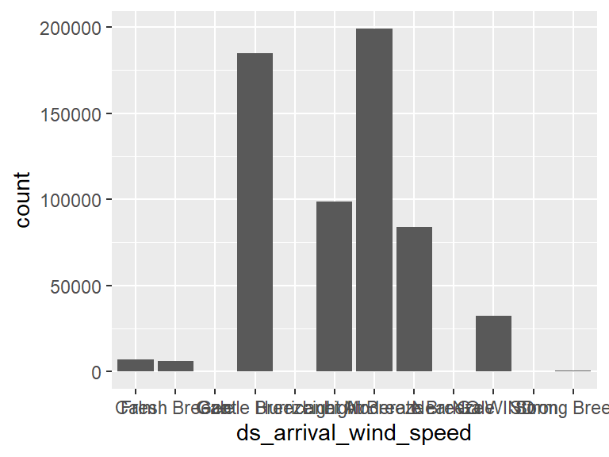

- Note that the following levels have at most five observations: "Hurricane", "Storm".

## arrival_wind_direction

| Feature | Result |
| --- | --- |
| Variable type | numeric |
| Number of missing obs. | 0 (0 %) |
| Number of unique values | 39 |
| Median | 120 |
| 1st and 3rd quartiles | 70; 190 |
| Min. and max. | 0; 360 |

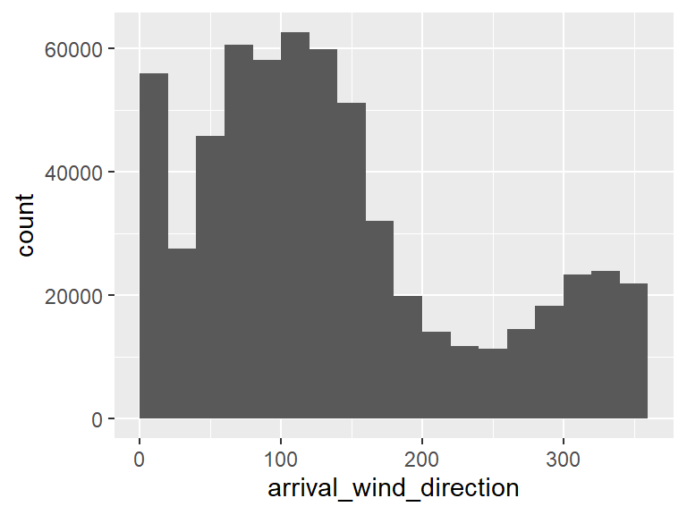

## ds_arrival_wind_direction

| Feature | Result |
| --- | --- |
| Variable type | factor |
| Number of missing obs. | 0 (0 %) |
| Number of unique values | 17 |
| Mode | “E” |
| Reference category | E |

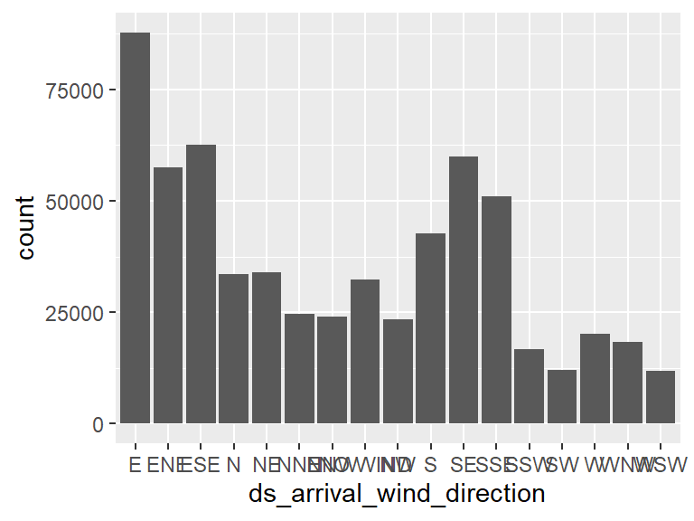

## ds_arrival_day_period

| Feature | Result |
| --- | --- |
| Variable type | ordered |
| Number of missing obs. | 0 (0 %) |
| Number of unique values | 7 |
| Mode | “Afternoon” |
| Reference category | Night |

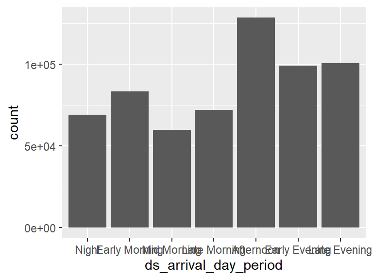

## situation_type

- The variable only takes one (non-missing) value: "REALIZADO". The variable contains 0 % missing observations.

## Partida_Atrasada

| Feature | Result |
| --- | --- |
| Variable type | character |
| Number of missing obs. | 0 (0 %) |
| Number of unique values | 2 |
| Mode | “0” |

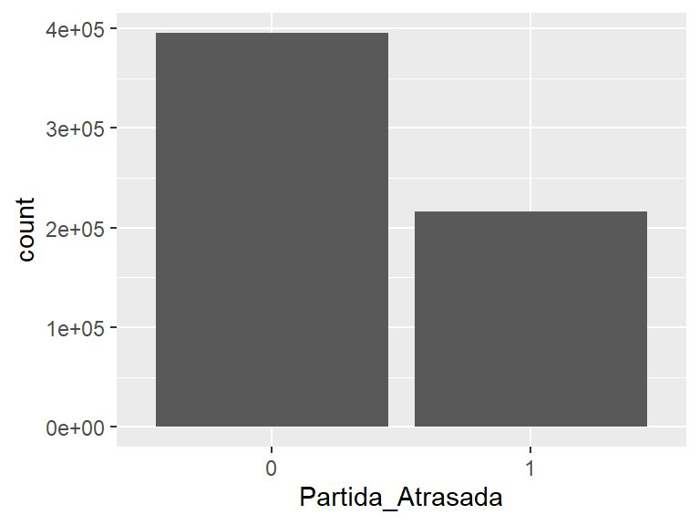

## Chegada_Atrasada

| Feature | Result |
| --- | --- |
| Variable type | character |
| Number of missing obs. | 0 (0 %) |
| Number of unique values | 2 |
| Mode | “0” |

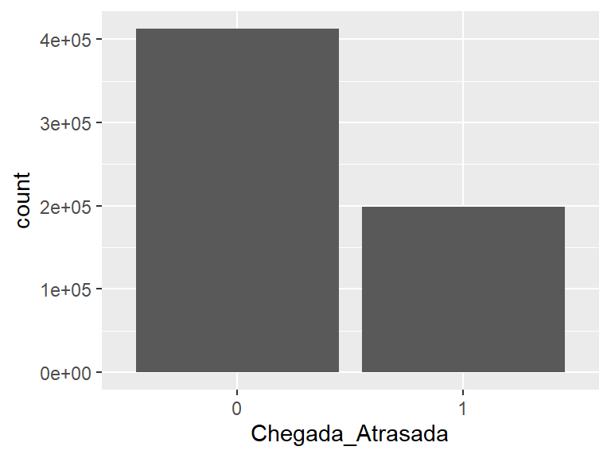

Report generation information:

- Created by: Uriel Merola Minage e Silva (username: `uriel.merola`).
- Report creation time: sáb jul 23 2022 01:05:19
- Report was run from directory: `D:/git/data-mining-class/data_preprocessing`
- dataMaid v1.4.1 [Pkg: 2021-10-08 from CRAN (R 4.2.1)]
- R version 4.2.1 (2022-06-23 ucrt).
- Platform: x86_64-w64-mingw32/x64 (64-bit)(Windows 10 x64 (build 19043)).
- Function call: `makeDataReport(data = dataframe, output = "html", replace = TRUE)`